# Part II - Window or aisle .. the ultimate guide to jetlag

## by Basel Zayyat

## Investigation Overview

This investigation was targeted at identifying the main drivers for delays and cancellations in order to be able to provide recommendations for the least impact of flight delays and cancellations.

It was observed that travellers flying Southwest, United Airlines and American Airlines, have suffered the most delays with the peak of delays concentrated between the hours 16:00 to 19:00 - a time window to avoid.

The top 10 planes impacted by delays and cancellations were United Airlines planes with the flight numbers 419, 65 and 343 suffering above average delays and cancellations

## Dataset Overview

The complete data set consists of flight arrival and departure details for all commercial flights within the USA, from October 1987 to April 2008. As the original dataset is ~120MM records and for the purposes of the analysis, this analysis will be limited to 3 years (1988,1998, and 2008). The choice of the years considered a systematic sample where an interval of 10 years was chosen to represent the sample population. The data was downloaded from the American Statistical Association from [here](http://ww2.amstat.org/sections/graphics/datasets/DataExpo2009.zip)  
where the original data set is collected by The data is collected by the Office of Airline Information, Bureau of Transportation Statistics (BTS), United States Department of Transportation. The original data set can be found [here](https://www.transtats.bts.gov/DatabaseInfo.asp?QO_VQ=EFD&Yv0x=D)  
The chosen sample contains 17,596,545 rows and represents ~ 15% of the total available data set with 29 columns.

For the purposes of this study a flight is considered delayed when it is 15 minutes later than its scheduled time and cancellation occurs when the airline does not operate the flight at all for a certain reason as per the The Federal Aviation Administration (FAA), details can be found [here](https://en.wikipedia.org/wiki/Flight_cancellation_and_delay)  
The sample dataset was further reduced into a subset that captures delays equal to or greater than 15 minutes and cancelled flights generating 4,400,236 rows and 29 columns for the analysis. This subset was saved as 'd_c_flights.csv' in the project folder.

## Carriers to avoid .. sometimes you just need to be picky!

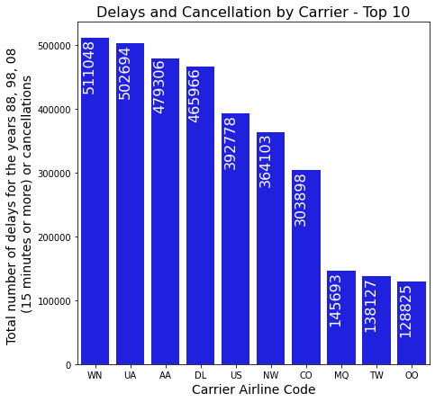

## Airport Nightmares .. not a cliche anymore

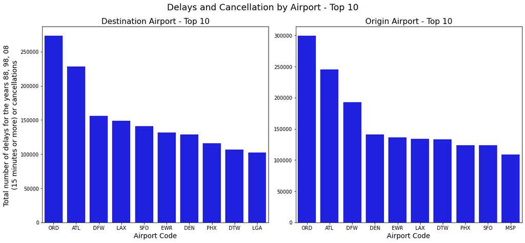

## RED eye flights .. You might wanna buckle up ..

Most of the delays occur during the period 16:00 to 19:00 - a time window to avoid, with red eye flight timings experiencing the least delays and cancellations

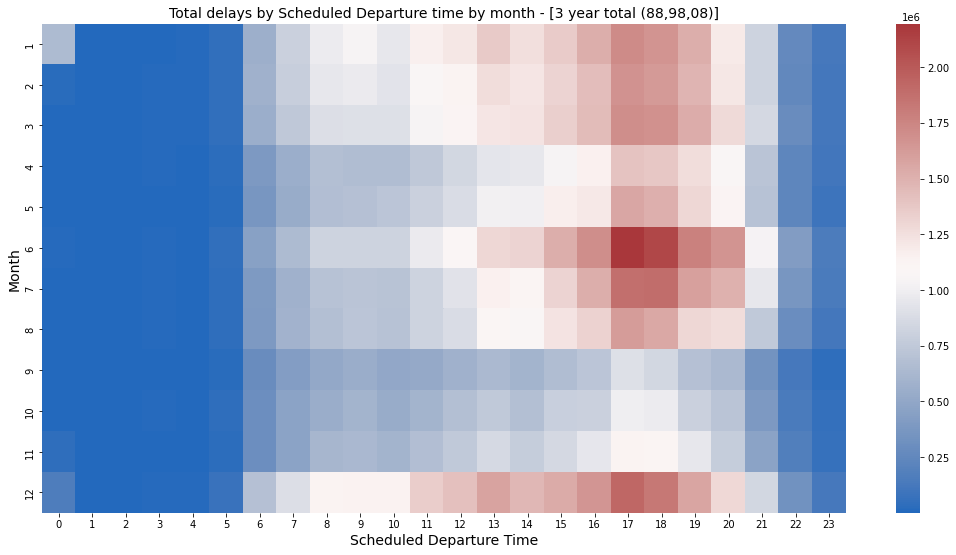